# House Prices: Advanced Regression Techniques

NYC Data Science Academy

## OUTLINE

1. Introduction
2. Loading Data
3. Visualizations
4. Pre-Processing
5. Model Training and Parameter Tuning
6. Variable Importance and Feature selection
7. Summary

## 1. Introduction

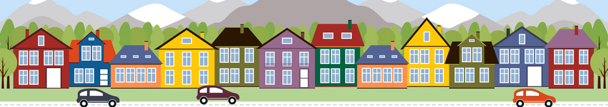

“Ask a home buyer to describe their dream house, and they probably won’t begin with the height of the basement ceiling or the proximity to an east-west railroad. But this playground competition’s dataset proves that much more influences price negotiations than the number of bedrooms or a white-picket fence.

With 79 explanatory variables describing (almost) every aspect of residential homes in Ames, Iowa, this problem challenges you to predict the final price of each home.

The potential for creative feature engineering provides a rich opportunity for fun and learning. This dataset lends itself to advanced regression techniques like random forests and gradient boosting with the popular XGBoost library."

## 2. Data Loading & Preparation

### 2.1 Loading data from csv

```r
setwd("C:/Users/cmlim/Dropbox/NYC Data Science/Class/Machine Learning Project/chungmeng")
## load training data
house_train <- read.csv("../data/train.csv",
                        header = TRUE,
                        na.strings = "",
                        stringsAsFactors = FALSE)
## load test data
house_test <- read.csv("../data/test.csv",
                        header = TRUE,
                        na.strings = "",
                        stringsAsFactors = FALSE)
dim(house_train)
```

```
## [1] 1460   81
```

```r
dim(house_test)
```

```
## [1] 1459   80
```

```r
str(house_train)
```

```
## 'data.frame':    1460 obs. of  81 variables:
##  $ Id           : int  1 2 3 4 5 6 7 8 9 10 ...
##  $ MSSubClass   : int  60 20 60 70 60 50 20 60 50 190 ...
##  $ MSZoning     : chr  "RL" "RL" "RL" "RL" ...
##  $ LotFrontage  : chr  "65" "80" "68" "60" ...
##  $ LotArea      : int  8450 9600 11250 9550 14260 14115 10084 10382 6120 7420 ...
##  $ Street       : chr  "Pave" "Pave" "Pave" "Pave" ...
##  $ Alley        : chr  "NA" "NA" "NA" "NA" ...
##  $ LotShape     : chr  "Reg" "Reg" "IR1" "IR1" ...
##  $ LandContour  : chr  "Lvl" "Lvl" "Lvl" "Lvl" ...
##  $ Utilities    : chr  "AllPub" "AllPub" "AllPub" "AllPub" ...
##  $ LotConfig    : chr  "Inside" "FR2" "Inside" "Corner" ...
##  $ LandSlope    : chr  "Gtl" "Gtl" "Gtl" "Gtl" ...
##  $ Neighborhood : chr  "CollgCr" "Veenker" "CollgCr" "Crawfor" ...
##  $ Condition1   : chr  "Norm" "Feedr" "Norm" "Norm" ...
```

[output cut: 67 more lines]

### 2.2 Getting factor levels from data description

```r
## get levels of categorical features from data description
factorLevel <- list()
conn <- file("../data/data_description.txt", open="r")
f <-readLines(conn)
for (line in f){
  if(!grepl("^[[:blank:]]", line) & grepl(": ", line)) {
    col_name <<- trimws(gsub(":.*", "", line))
  } else {
    level <- trimws(gsub("\t.*", "", line))
    if (level != "") {
      factorLevel[[col_name]] <- c(factorLevel[[col_name]], level)
    }
  }
}
close(conn)

print(factorLevel[1:6])
```

```
## $MSSubClass
##  [1] "20"  "30"  "40"  "45"  "50"  "60"  "70"  "75"  "80"  "85"  "90"
## [12] "120" "150" "160" "180" "190"
##
## $MSZoning
## [1] "A"  "C"  "FV" "I"  "RH" "RL" "RP" "RM"
##
## $Street
## [1] "Grvl" "Pave"
##
## $Alley
## [1] "Grvl" "Pave" "NA"
##
## $LotShape
## [1] "Reg" "IR1" "IR2" "IR3"
##
## $LandContour
## [1] "Lvl" "Bnk" "HLS" "Low"
```

### 2.3 Checking factor levels with data

```r
## check if levels in description cover unique data values
for (varname in names(factorLevel)) {
  levelDiff <- setdiff(unique(house_train[[varname]]),
                       factorLevel[[varname]])
  if(length(levelDiff)) {
    print(paste(varname,
                paste(levelDiff, collapse = ", "),
                sep = ": "))
  }
}
```

```
## [1] "MSZoning: C (all)"
## [1] "Neighborhood: NAmes"
## [1] "BldgType: 2fmCon, Duplex, Twnhs"
## [1] "Exterior2nd: Wd Shng, CmentBd, Brk Cmn"
## [1] "MasVnrType: NA"
## [1] "Electrical: NA"
```

### 2.4 Fixing level names

```r
## fix those levels that don't match with data
## ignore "NA" as they will be considered as missing when converting categorical to factors

unique(house_train$MSZoning)
```

```
## [1] "RL"      "RM"      "C (all)" "FV"      "RH"
```

```r
factorLevel$MSZoning
```

```
## [1] "A"  "C"  "FV" "I"  "RH" "RL" "RP" "RM"
```

```r
factorLevel$MSZoning[2] <- "C (all)"

unique(house_train$Neighborhood)
```

```
##  [1] "CollgCr" "Veenker" "Crawfor" "NoRidge" "Mitchel" "Somerst" "NWAmes"
##  [8] "OldTown" "BrkSide" "Sawyer"  "NridgHt" "NAmes"   "SawyerW" "IDOTRR"
## [15] "MeadowV" "Edwards" "Timber"  "Gilbert" "StoneBr" "ClearCr" "NPkVill"
## [22] "Blmngtn" "BrDale"  "SWISU"   "Blueste"
```

```r
factorLevel$Neighborhood
```

```
##  [1] "Blmngtn" "Blueste" "BrDale"  "BrkSide" "ClearCr" "CollgCr" "Crawfor"
##  [8] "Edwards" "Gilbert" "IDOTRR"  "MeadowV" "Mitchel" "Names"   "NoRidge"
## [15] "NPkVill" "NridgHt" "NWAmes"  "OldTown" "SWISU"   "Sawyer"  "SawyerW"
## [22] "Somerst" "StoneBr" "Timber"  "Veenker"
```

```r
factorLevel$Neighborhood[13] <- "NAmes"

unique(house_train$BldgType)
```

```
## [1] "1Fam"   "2fmCon" "Duplex" "TwnhsE" "Twnhs"
```

```r
factorLevel$BldgType
```

```
## [1] "1Fam"   "2FmCon" "Duplx"  "TwnhsE" "TwnhsI"
```

```r
factorLevel$BldgType[c(2,3,5)] <- c("2fmCon","Duplex","Twnhs")

unique(house_train$Exterior2nd)
```

```
##  [1] "VinylSd" "MetalSd" "Wd Shng" "HdBoard" "Plywood" "Wd Sdng" "CmentBd"
##  [8] "BrkFace" "Stucco"  "AsbShng" "Brk Cmn" "ImStucc" "AsphShn" "Stone"
## [15] "Other"   "CBlock"
```

```r
factorLevel$Exterior2nd
```

```
##  [1] "AsbShng" "AsphShn" "BrkComm" "BrkFace" "CBlock"  "CemntBd" "HdBoard"
##  [8] "ImStucc" "MetalSd" "Other"   "Plywood" "PreCast" "Stone"   "Stucco"
## [15] "VinylSd" "Wd Sdng" "WdShing"
```

```r
factorLevel$Exterior2nd[c(17,6,3)] <- c("Wd Shng","CmentBd","Brk Cmn")

## Get levels that only appear in the dataset
for (varname in names(factorLevel)) {
  factorLevel[[varname]] <- intersect(factorLevel[[varname]],
                                      unique(house_train[[varname]]))
}

## Re-run the previous cell to double check
```

### 2.5 Converting column data types

```r
## convert column datatype to numeric / factor
## On training dataset
for (varname in names(house_train)[-1]) {
  if (varname %in% names(factorLevel)) {
    house_train[[varname]] <- factor(house_train[[varname]],
                                     levels = factorLevel[[varname]])
  } else {
    house_train[[varname]] <- as.numeric(house_train[[varname]])
  }
}

## On testing dataset
for (varname in names(house_test)[-1]) {
  if (varname %in% names(factorLevel)) {
    house_test[[varname]] <- factor(house_test[[varname]],
                                    levels = factorLevel[[varname]])
  } else {
    house_test[[varname]] <- as.numeric(house_test[[varname]])
  }
}
```

### 2.6 (Optional) Saving data

```r
house_train$Id <- NULL
rownames(house_test) <- house_test$Id
house_test$Id <- NULL
save(house_train, house_test, file = "./house_loaded.RData")
```

## 3. Visualizations

### Loading data (from step 2)

```r
library(ggplot2)
library(gridExtra)
library(tabplot)
library(lsr)
library(corrplot)
library(dplyr)

rm(list = ls())
load("./house_loaded.RData")
```

### 3.1 SalePrice Histogram

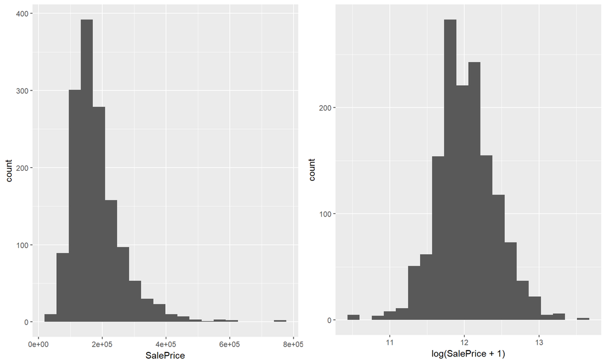

```r
## histogram on SalePrice
grid.arrange(ggplot(house_train) +
               geom_histogram(aes(SalePrice), bins = 20),
             ggplot(house_train) +
               geom_histogram(aes(log(SalePrice + 1)), bins = 20),
             ncol = 2)
```

### 3.2 Plotting all features sorted by SalePrice

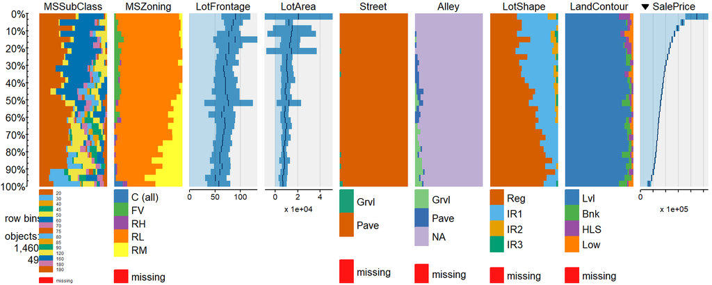

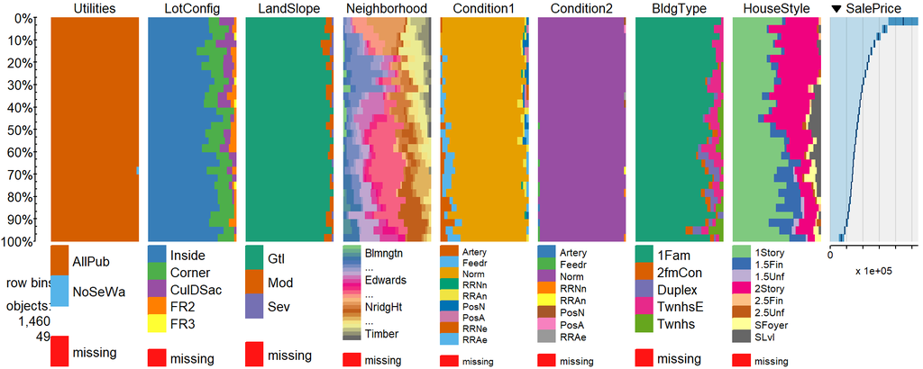

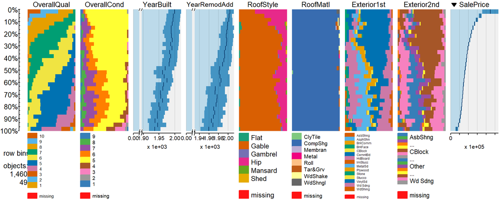

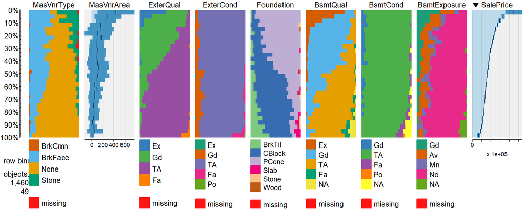

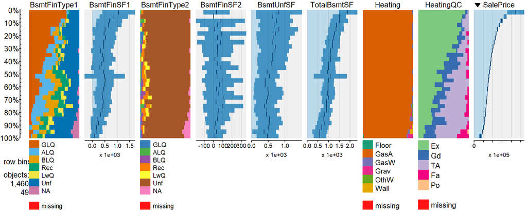

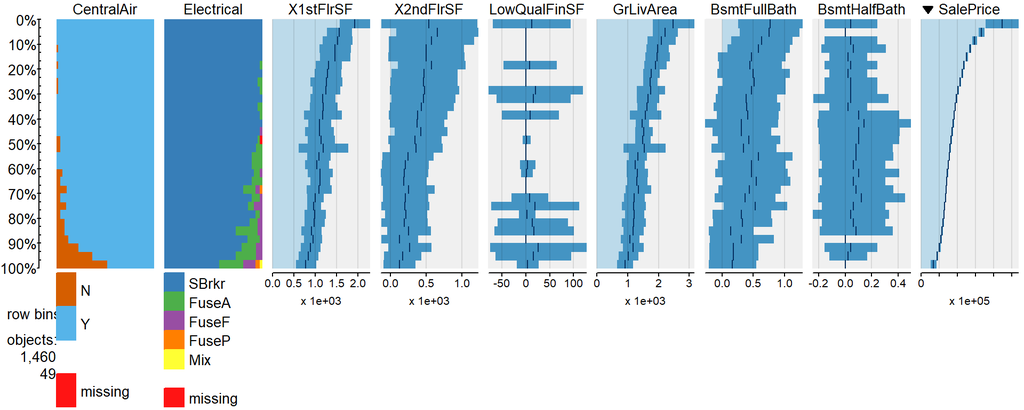

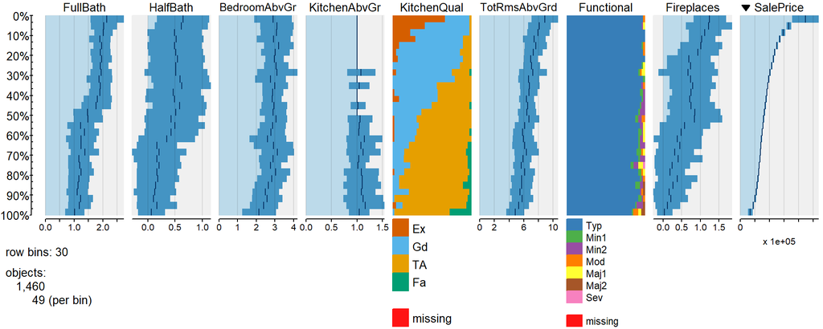

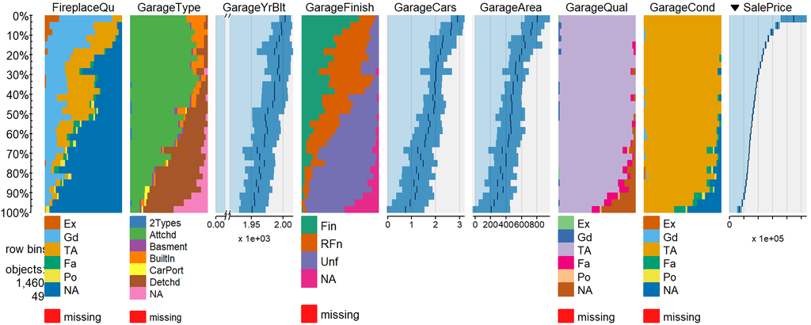

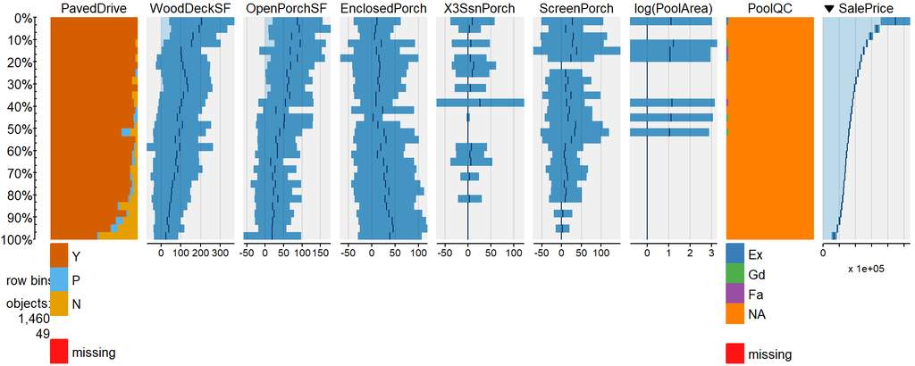

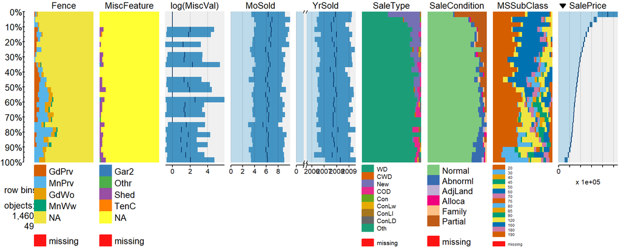

```r
## table plot all features on sortded SalePrice
colMtx <- matrix(names(house_train)[1:length(house_train)-1], nrow = 8)
for (i in 1:ncol(colMtx)) {
  tableplot(house_train,
            select_string = c(colMtx[,i], "SalePrice"),
            sortCol = "SalePrice", decreasing = TRUE,
            nBins = 30)
}
```

### 3.3 Correlations between Continuous Variables

```r
numeric_features <- names(house_train)[sapply(house_train, is.numeric)]
numeric_features <- numeric_features[-length(numeric_features)]
print(numeric_features)
```

```
##  [1] "LotFrontage"   "LotArea"       "YearBuilt"     "YearRemodAdd"
##  [5] "MasVnrArea"    "BsmtFinSF1"    "BsmtFinSF2"    "BsmtUnfSF"
##  [9] "TotalBsmtSF"   "X1stFlrSF"     "X2ndFlrSF"     "LowQualFinSF"
## [13] "GrLivArea"     "BsmtFullBath"  "BsmtHalfBath"  "FullBath"
## [17] "HalfBath"      "BedroomAbvGr"  "KitchenAbvGr"  "TotRmsAbvGrd"
## [21] "Fireplaces"    "GarageYrBlt"   "GarageCars"    "GarageArea"
## [25] "WoodDeckSF"    "OpenPorchSF"   "EnclosedPorch" "X3SsnPorch"
## [29] "ScreenPorch"   "PoolArea"      "MiscVal"       "MoSold"
## [33] "YrSold"
```

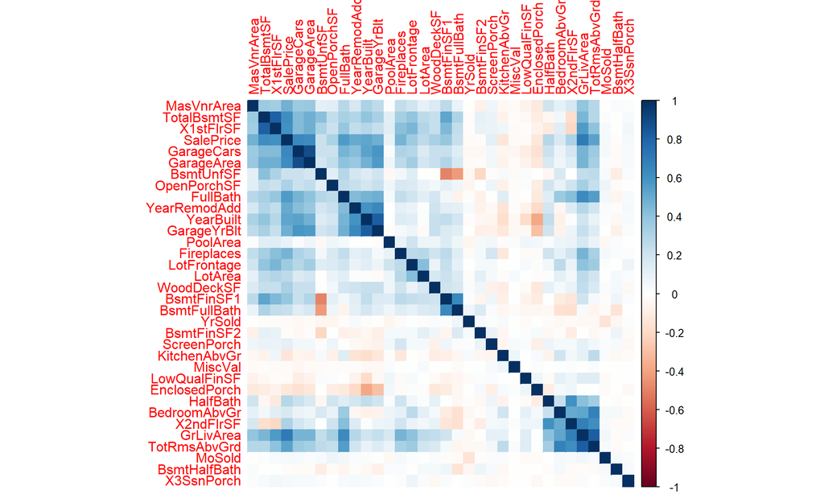

```r
## correlation between continuous variables in training dataset - pearson
corr_numtran <- cor(house_train %>%
                      select(one_of(numeric_features, "SalePrice")),
                    method = "pearson",
                    use = "pairwise.complete.obs")

corrplot(corr_numtran, method = "color", order="hclust")
```

```r
## correlation between continuous variables in test dataset - pearson
# corr_numtest <- cor(house_test %>%
#                       select(one_of(numeric_features)),
#                     method = "pearson",
#                     use = "pairwise.complete.obs")
#
# corrplot(corr_numtest, method = "color", order="hclust")
```

### 3.4 Correlations between Ordinal Variables

```r
## ordinal features are those who contain one of the follow levels
ordinal_levels <- c("Reg", "5", "TA", "No", "Unf",
                    "MnPrv", "Y", "Mod", "HLS", "1Fam")
ordinal_features <- character(0)

for(feature in names(house_train)) {
  if(is.factor(house_train[,feature]) &&
     length(intersect(ordinal_levels, levels(house_train[,feature])))) {
    ordinal_features <- c(ordinal_features, feature)
  }
}

print(ordinal_features)
```

```
##  [1] "LotShape"     "LandContour"  "LandSlope"    "BldgType"
##  [5] "OverallQual"  "OverallCond"  "ExterQual"    "ExterCond"
##  [9] "BsmtQual"     "BsmtCond"     "BsmtExposure" "BsmtFinType1"
## [13] "BsmtFinType2" "HeatingQC"    "CentralAir"   "KitchenQual"
## [17] "Functional"   "FireplaceQu"  "GarageFinish" "GarageQual"
## [21] "GarageCond"   "PavedDrive"   "Fence"
```

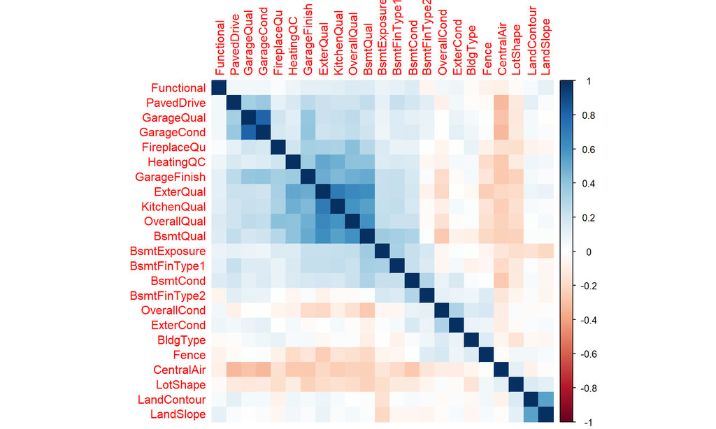

```r
## correlation between ordinal variables in training dataset - kendall
corr_ordtran <- cor(data.matrix(house_train %>%
                                  select(one_of(ordinal_features))),
                    method = "kendall",
                    use = "pairwise.complete.obs")

corrplot(corr_ordtran, method = "color", order="hclust")
```

```r
## correlation between ordinal variables in test dataset - kendall
# corr_ordtest <- cor(data.matrix(house_test %>%
#                                   select(one_of(ordinal_features))),
#                     method = "kendall",
#                     use = "pairwise.complete.obs")
#
# corrplot(corr_ordtest, method = "color", order="hclust")
```

### 3.5 Correlations between Nominal Variables

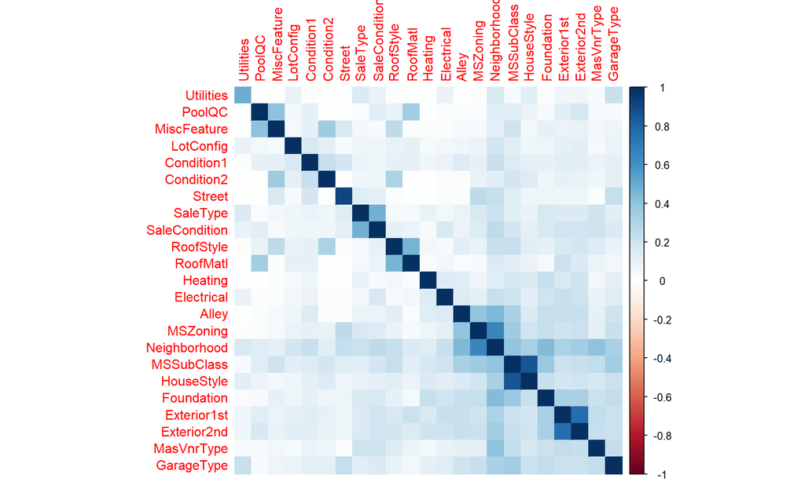

```r
## CramÃ©r's V is a measure of association between two nominal variables, giving a value between 0 and +1 (inclusive)
cor.cramersV <- function(data) {
  cramersV(table(data[complete.cases(data),]))
}

nominal_features <- setdiff(names(house_train),
                            c(numeric_features, ordinal_features, "SalePrice"))


## cramers V in test dataset
corr_nomtran <- sapply(nominal_features,
                       function(x) sapply(nominal_features,
                                          function(y) cor.cramersV(house_train[, c(x, y)])))

corrplot(corr_nomtran, method = "color", order="hclust")
```

### 3.6 Correlations between Ordinal Variables vs. SalePrice

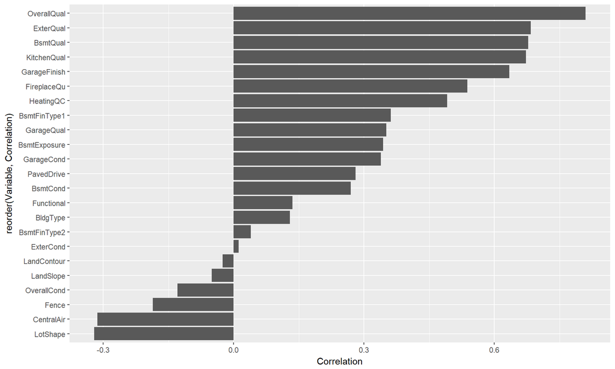

```r
## coorelation between ordered categorical variables in training - spearman
cor.ordcnt <- function(data, x, y) {
  cor(as.numeric(data[[x]]), as.numeric(data[[y]]),
                 method = "spearman",
                 use = "pairwise.complete.obs")
}

corr_ordcnttran <- data.frame(Variable = ordinal_features,
                              Correlation = sapply(ordinal_features,
                                                function(x) -cor.ordcnt(house_train, x, "SalePrice")))

ggplot(corr_ordcnttran, aes(reorder(Variable, Correlation), Correlation)) +
  geom_bar(stat = "identity") +
  coord_flip()
```

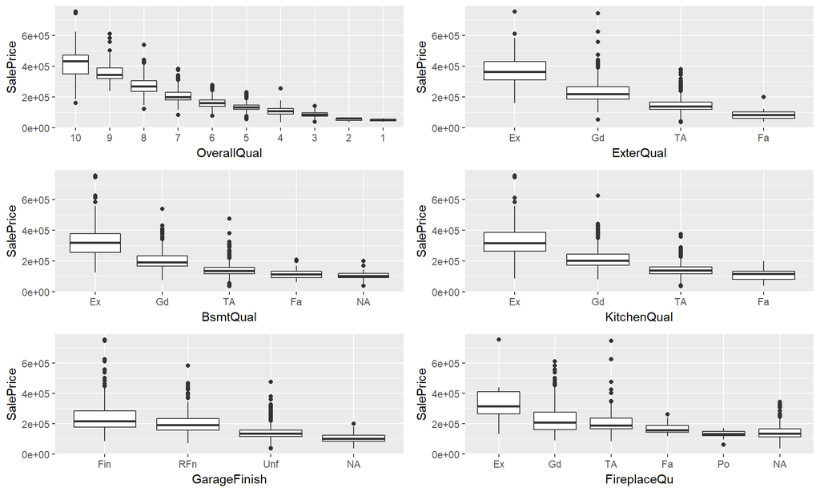

```r
## Might be a good idea to convert some ordinal predictors to continuous
grid.arrange(
  ggplot(house_train, aes(x = OverallQual, y = SalePrice)) + geom_boxplot(),
  ggplot(house_train, aes(x = ExterQual, y = SalePrice)) + geom_boxplot(),
  ggplot(house_train, aes(x = BsmtQual, y = SalePrice)) + geom_boxplot(),
  ggplot(house_train, aes(x = KitchenQual, y = SalePrice)) + geom_boxplot(),
  ggplot(house_train, aes(x = GarageFinish, y = SalePrice)) + geom_boxplot(),
  ggplot(house_train, aes(x = FireplaceQu, y = SalePrice)) + geom_boxplot(),
  ncol = 2
)
```

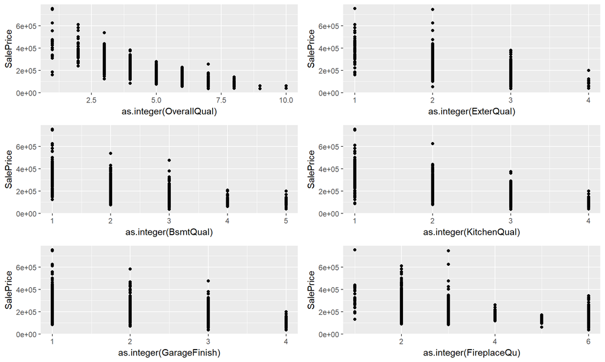

```r
grid.arrange(
  ggplot(house_train, aes(x = as.integer(OverallQual), y = SalePrice)) + geom_point(),
  ggplot(house_train, aes(x = as.integer(ExterQual), y = SalePrice)) + geom_point(),
  ggplot(house_train, aes(x = as.integer(BsmtQual), y = SalePrice)) + geom_point(),
  ggplot(house_train, aes(x = as.integer(KitchenQual), y = SalePrice)) + geom_point(),
  ggplot(house_train, aes(x = as.integer(GarageFinish), y = SalePrice)) + geom_point(),
  ggplot(house_train, aes(x = as.integer(FireplaceQu), y = SalePrice)) + geom_point(),
  ncol = 2
)
```

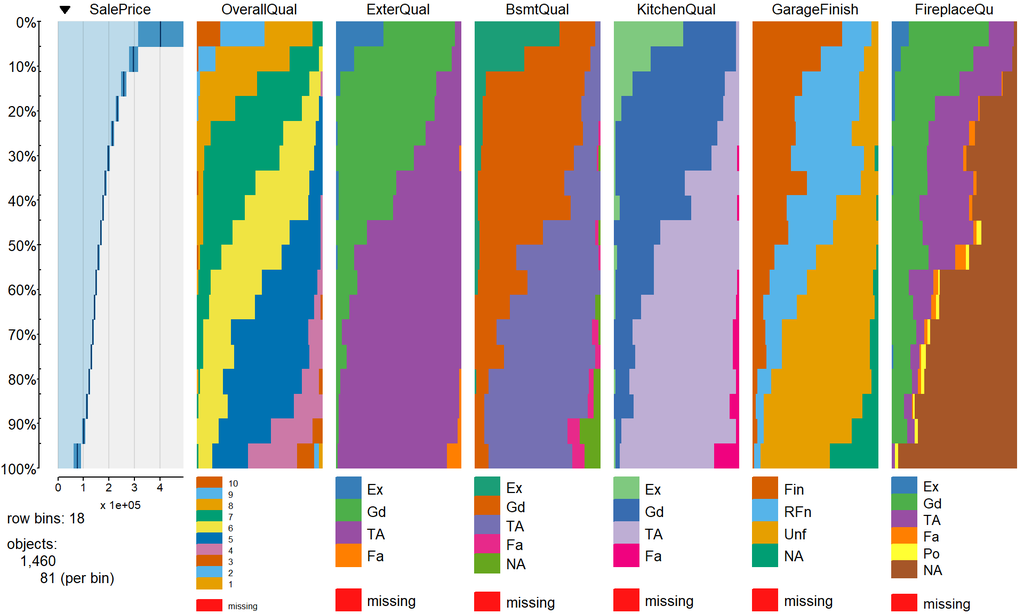

```r
tableplot(house_train %>% select(one_of("SalePrice","OverallQual", "ExterQual", "BsmtQual",
                                        "KitchenQual", "GarageFinish", "FireplaceQu")),
          decreasing = TRUE,
          nBins = 18,
          colorNA = "#FF1414", colorNA_num = "#FF1414")
```

## 4. Pre-Processing

### 4.1 Understanding Missingness

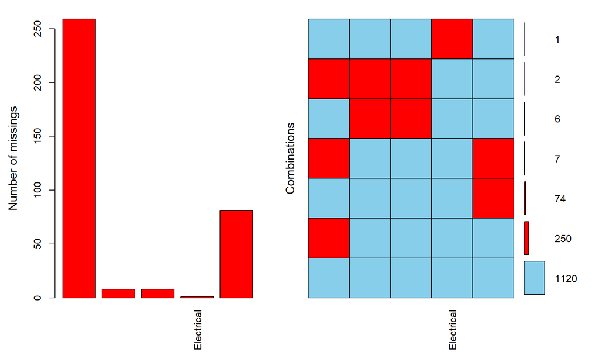

```r
library(VIM)
library(caret)
library(RANN)
## check missing values
col_missing <- names(house_train)[colSums(is.na(house_train)) > 0]
aggr(house_train[,col_missing], prop = F, numbers = T)
```

```r
Filter(function(x) x > 0, colSums(is.na(house_train)))
```

```
## LotFrontage  MasVnrType  MasVnrArea  Electrical GarageYrBlt
##         259           8           8           1          81
```

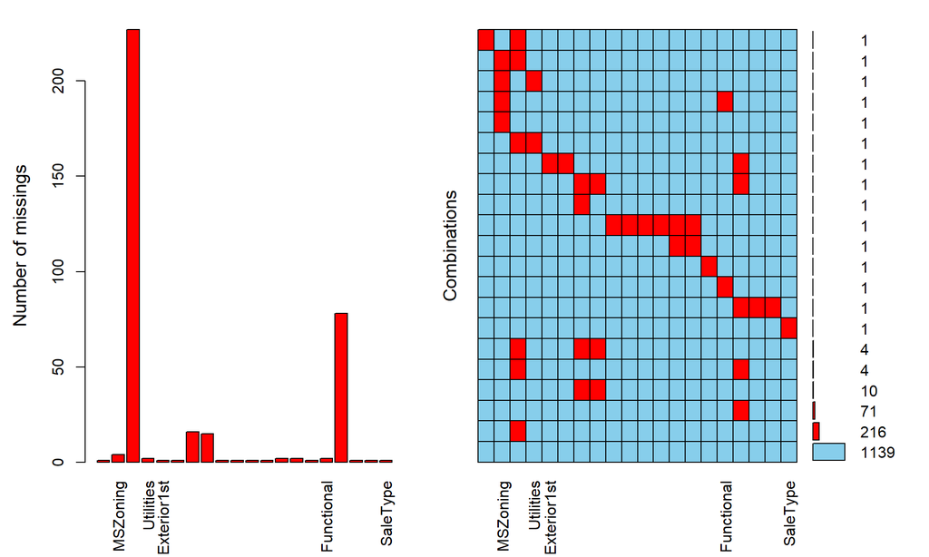

```r
col_missing <- names(house_test)[colSums(is.na(house_test)) > 0]
aggr(house_test[,col_missing], prop = F, numbers = T)
```

```r
Filter(function(x) x > 0, colSums(is.na(house_test)))
```

```
##   MSSubClass     MSZoning  LotFrontage    Utilities  Exterior1st
##            1            4          227            2            1
##  Exterior2nd   MasVnrType   MasVnrArea   BsmtFinSF1   BsmtFinSF2
##            1           16           15            1            1
##    BsmtUnfSF  TotalBsmtSF BsmtFullBath BsmtHalfBath  KitchenQual
##            1            1            2            2            1
##   Functional  GarageYrBlt   GarageCars   GarageArea     SaleType
##            2           78            1            1            1
```

### 4.2 Missing Pattern of GarageYrBlt

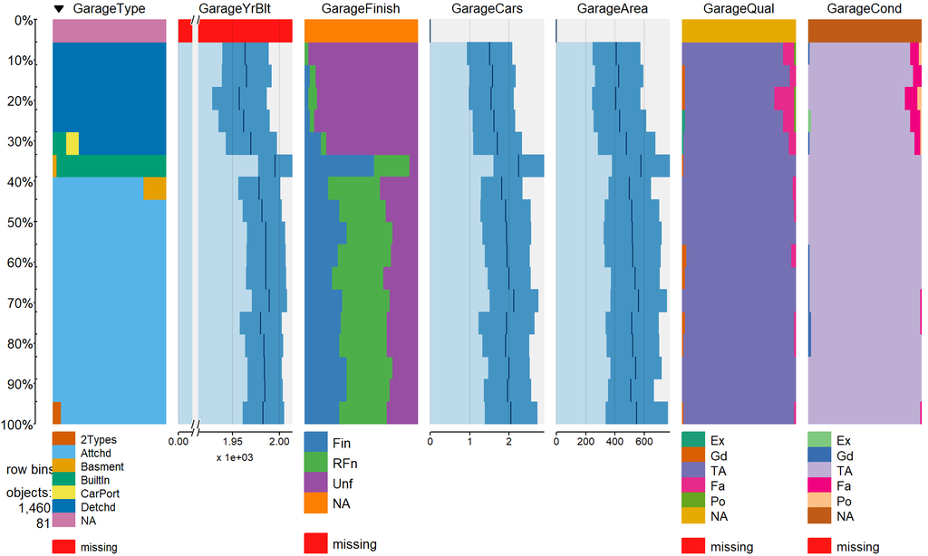

```r
## table plot all features on sortded SalePrice
tableplot(house_train %>% select(starts_with("Garage")),
          decreasing = TRUE,
          nBins = 18,
          colorNA = "#FF1414", colorNA_num = "#FF1414")
```

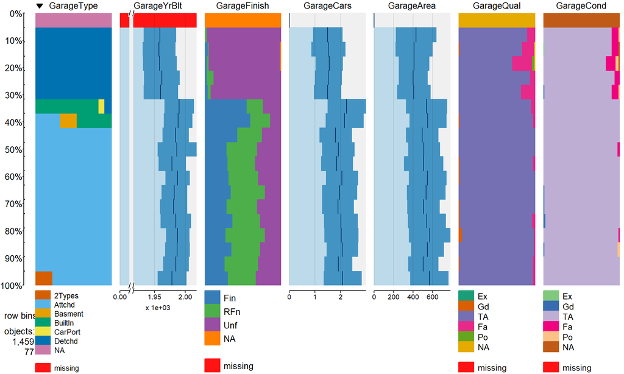

```r
tableplot(house_test %>% select(starts_with("Garage")),
          decreasing = TRUE,
          nBins = 19,
          colorNA = "#FF1414", colorNA_num = "#FF1414")
```

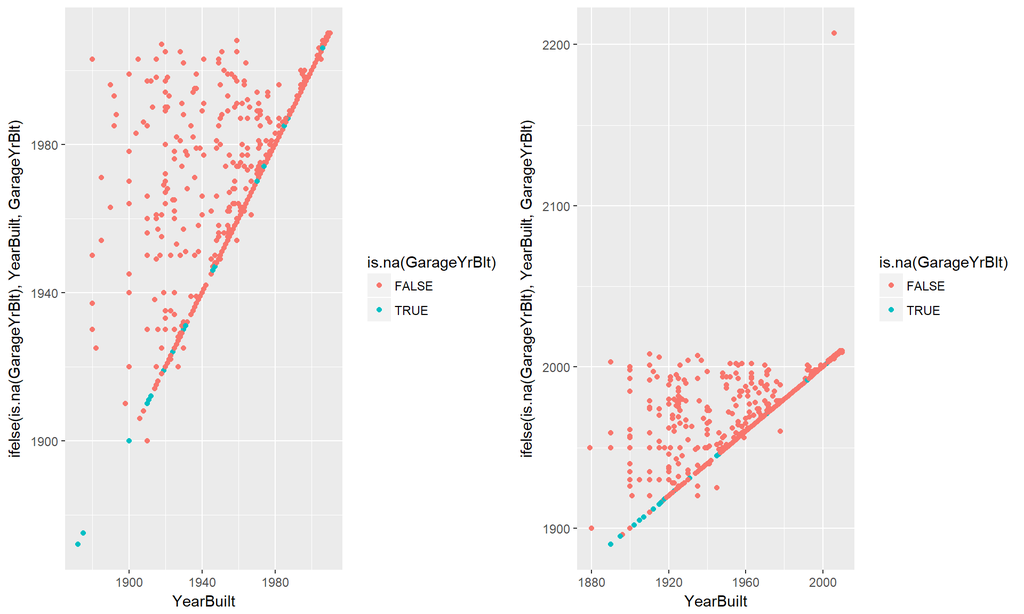

```r
grid.arrange(
  ggplot(house_train,
         aes(YearBuilt, ifelse(is.na(GarageYrBlt), YearBuilt, GarageYrBlt))) +
    geom_point(aes(color = is.na(GarageYrBlt))),
  ggplot(house_test,
         aes(YearBuilt, ifelse(is.na(GarageYrBlt), YearBuilt, GarageYrBlt))) +
    geom_point(aes(color = is.na(GarageYrBlt))),
  ncol = 2
)
```

### 4.3 Imputing GarageYrBlt

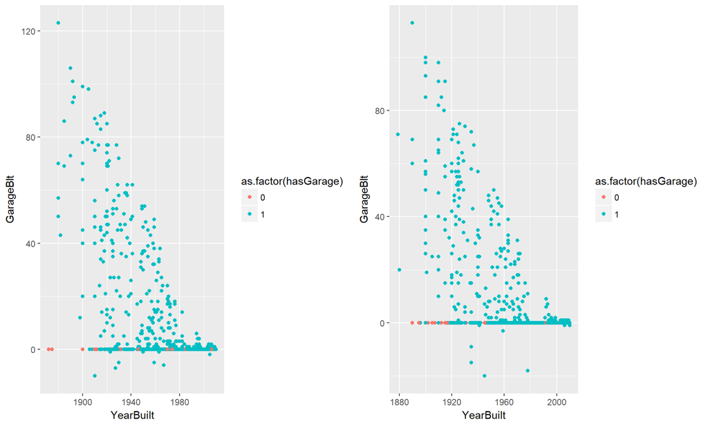

```r
## Fix outlier
house_test$GarageYrBlt[which(house_test$GarageYrBlt == 2207)] <- 2007

## Create new feature: hasGarage
## Impute GarageYrBlt with YearBuilt
house_train <- house_train %>%
  mutate(hasGarage = ifelse(is.na(GarageYrBlt), 0, 1),
         GarageBlt = ifelse(is.na(GarageYrBlt), 0, GarageYrBlt - YearBuilt)) %>%
  select(-GarageYrBlt)

house_test <- house_test %>%
  mutate(hasGarage = ifelse(is.na(GarageYrBlt), 0, 1),
         GarageBlt = ifelse(is.na(GarageYrBlt), 0, GarageYrBlt - YearBuilt)) %>%
  select(-GarageYrBlt)

grid.arrange(
  ggplot(house_train, aes(YearBuilt, GarageBlt)) +
    geom_point(aes(color = as.factor(hasGarage))),
  ggplot(house_test, aes(YearBuilt, GarageBlt)) +
    geom_point(aes(color = as.factor(hasGarage))),
  ncol = 2
)
```

### 4.4 Transforming YearRemodAdd

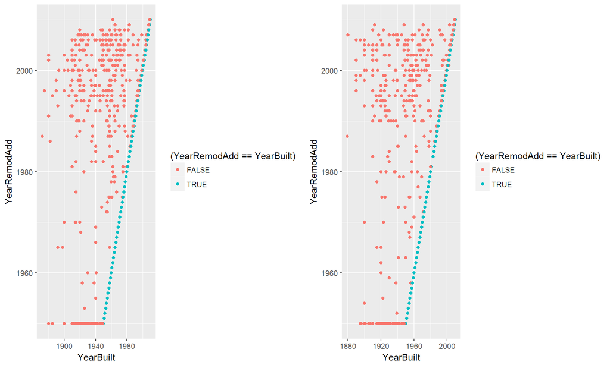

```r
grid.arrange(
  ggplot(house_train, aes(YearBuilt, YearRemodAdd)) +
    geom_point(aes(color = (YearRemodAdd == YearBuilt))),
  ggplot(house_test, aes(YearBuilt, YearRemodAdd)) +
    geom_point(aes(color = (YearRemodAdd == YearBuilt))),
  ncol = 2
)
```

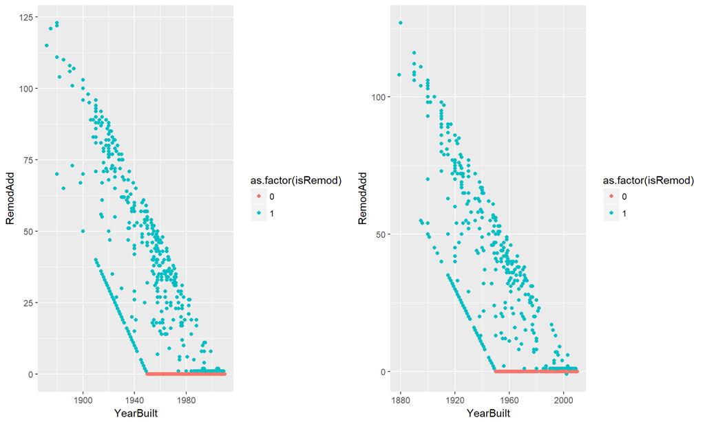

```r
house_train <- house_train %>%
  mutate(isRemod = ifelse(YearRemodAdd == YearBuilt, 0, 1),
         RemodAdd = YearRemodAdd - YearBuilt) %>%
  select(-YearRemodAdd)

house_test <- house_test %>%
  mutate(isRemod = ifelse(YearRemodAdd == YearBuilt, 0, 1),
         RemodAdd = YearRemodAdd - YearBuilt) %>%
  select(-YearRemodAdd)

grid.arrange(
  ggplot(house_train, aes(YearBuilt,RemodAdd)) +
    geom_point(aes(color = as.factor(isRemod))),
  ggplot(house_test, aes(YearBuilt, RemodAdd)) +
    geom_point(aes(color = as.factor(isRemod))),
  ncol = 2
)
```

### 4.5 Zero- and near Zero-Variance Predictors

```r
nzv <- nearZeroVar(house_train[, -length(house_train)],
                   freqCut = 99/1,
                   uniqueCut = 5,
                   saveMetrics= TRUE)
nzv[nzv$nzv,]
```

```
##              freqRatio percentUnique zeroVar  nzv
## Street        242.3333     0.1369863   FALSE TRUE
## Utilities    1459.0000     0.1369863   FALSE TRUE
## Condition2    240.8333     0.5479452   FALSE TRUE
## RoofMatl      130.3636     0.5479452   FALSE TRUE
## LowQualFinSF  478.0000     1.6438356   FALSE TRUE
## X3SsnPorch    478.6667     1.3698630   FALSE TRUE
## PoolArea     1453.0000     0.5479452   FALSE TRUE
## PoolQC        484.3333     0.2739726   FALSE TRUE
## MiscVal       128.0000     1.4383562   FALSE TRUE
```

```r
house_train[, rownames(nzv[nzv$nzv,])] <- NULL
house_test[, rownames(nzv[nzv$nzv,])] <- NULL
dim(house_train)
```

```
## [1] 1460   73
```

```r
dim(house_test)
```

```
## [1] 1459   72
```

### 4.6 Imputing other Features using KNN

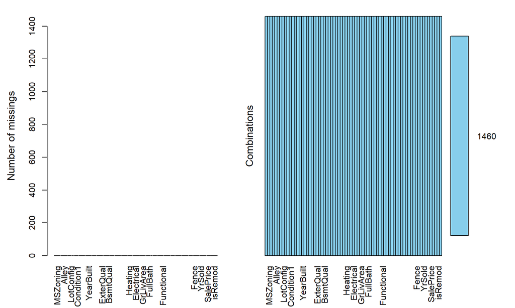

```r
## use knn to impute all numerical varialbes
# preProc_numerical <- preProcess(house_train[, -length(house_train)],
#                                 method = c("knnImpute"))
# print(preProc_numerical)
# house_train[, -length(house_train)] <- predict(preProc_numerical,
#                               house_train[, -length(house_train)])
# house_test <- predict(preProc_numerical, house_test)

## Caret only handles numerical features
## use kNN to impute categorical features
house_train[, -length(house_train)] <- kNN(house_train[, -length(house_train)],
                                           k=5)[,names(house_train)[-length(house_train)]]
house_test <- kNN(house_test, k=5)[,names(house_test)]

## Double check missingness with the following code
aggr(house_train, prop = F, numbers = T)
```

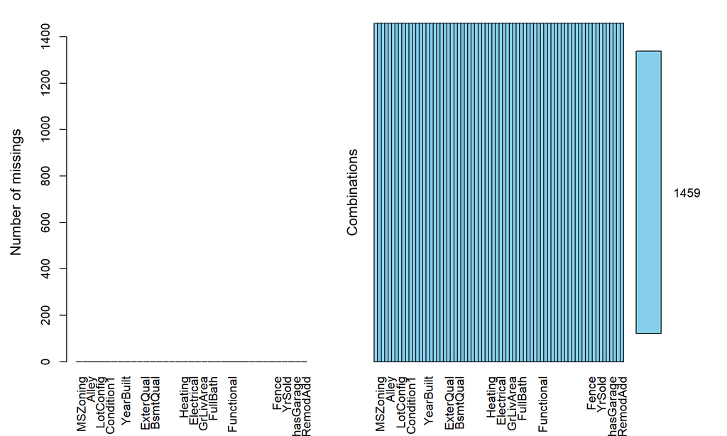

```r
aggr(house_test, prop = F, numbers = T)
```

### 4.7 Transforming `SalePrice` to log scale

```r
## Transform SalePrice to log scale
house_train$SalePrice <- log(house_train$SalePrice + 1)
```

### 4.8 (Optional) Saving data

```r
save(house_train, house_test, file = "./house_preProc.RData")
```

# Modeling

## 5.1 Model Training and Parameter Tuning

### Loading data (from step 4)

```r
rm(list = ls()) # clear workspace
library(caret)
load("./house_preProc.RData")
```

### 5.2 Data Splitting using `createDataPartiton`

```r
## Perform single 80%/20% random split of house_train
library(caret)
set.seed(321)
trainIdx <- createDataPartition(house_train$SalePrice,
                                p = .8,
                                list = FALSE,
                                times = 1)
subTrain <- house_train[trainIdx,]
subTest <- house_train[-trainIdx,]
print(head(subTrain))
```

```
##   MSSubClass MSZoning LotFrontage LotArea Alley LotShape LandContour
## 1         60       RL          65    8450    NA      Reg         Lvl
## 2         20       RL          80    9600    NA      Reg         Lvl
## 3         60       RL          68   11250    NA      IR1         Lvl
## 4         70       RL          60    9550    NA      IR1         Lvl
## 5         60       RL          84   14260    NA      IR1         Lvl
## 6         50       RL          85   14115    NA      IR1         Lvl
##   LotConfig LandSlope Neighborhood Condition1 BldgType HouseStyle
## 1    Inside       Gtl      CollgCr       Norm     1Fam     2Story
## 2       FR2       Gtl      Veenker      Feedr     1Fam     1Story
## 3    Inside       Gtl      CollgCr       Norm     1Fam     2Story
## 4    Corner       Gtl      Crawfor       Norm     1Fam     2Story
## 5       FR2       Gtl      NoRidge       Norm     1Fam     2Story
## 6    Inside       Gtl      Mitchel       Norm     1Fam     1.5Fin
##   OverallQual OverallCond YearBuilt RoofStyle Exterior1st Exterior2nd
```

[output cut: 69 more lines]

### 5.2 Setting up resampling method using `trainControl`

```r
set.seed(456)
fitCtrl <- trainControl(method = "repeatedcv",
                        number = 5,
                        repeats = 3,
                        verboseIter = FALSE,
                        summaryFunction = defaultSummary)
```

## 6.1 Basic Linear Regression

First of all let’s build a **multiple linear model** to use all predictors to predict **SalePrice**:

- Train ML model with **train**
- Evaluate variable importance
- Predict on test dataset with **predict**
- Measure performance

```r
lmFit <- train(SalePrice ~., data = subTrain,
               method = "lm")
# summary(lmFit)
## Call:
## lm(formula = .outcome ~ ., data = dat)
## ... ...
## Residual standard error: 0.1152 on 915 degrees of freedom
## Multiple R-squared:  0.935,  Adjusted R-squared:  0.917
## F-statistic:    52 on 253 and 915 DF,  p-value: < 2.2e-16
```

### 6.2 Linear Regression Variable Importance

```r
lmImp <- varImp(lmFit, scale = FALSE)
## lm variable importance
##
##  only 20 most important variables shown (out of 253)
##
##                      Overall
## MSZoningRL             8.151
## MSZoningFV             7.881
## MSZoningRM             7.659
## MSZoningRH             6.977
## SaleConditionAbnorml   5.433
## OverallQual1           5.309
## LandContourBnk         4.292
```

Note: linear models use the absolute value of the t-statistic.

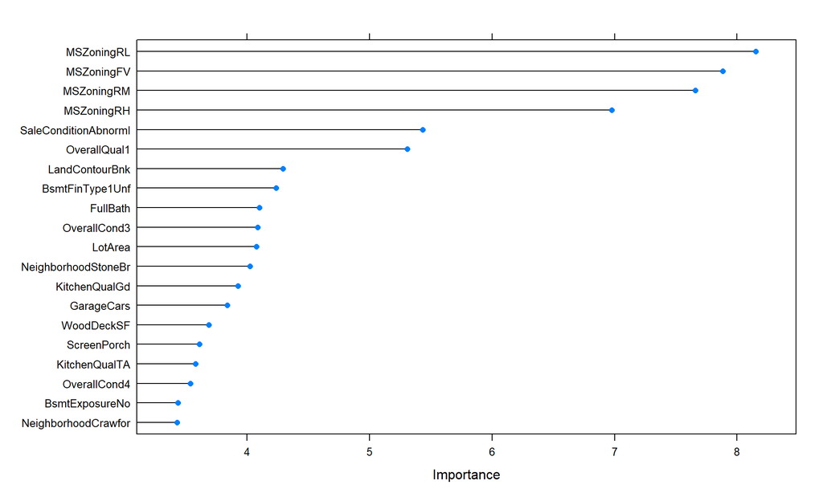

```r
plot(lmImp, top = 20)
```